# Reproducible Research: Peer Assessment 1

Chris Kerrigan

November 18, 2016

## Loading and preprocessing the data

Below are the steps required to read in the activity data. Since the data is already tidy, there is no need for any preprocessing at the moment. Any manipulations to the data required for future steps will be performed at that time.

```r
setwd('C:/Users/ckerriga/Documents/Coursera/Project Data')
data <- read.csv('activity.csv')
```

## What is mean total number of steps taken per day?

For this part of the assignment, we wish to ignore missing values in the dataset. We will do this by creating a new data set called **dataNoNA**. After creating this new data set, we will create a histogram (using R base plotting system) of the total number of steps taken each day.

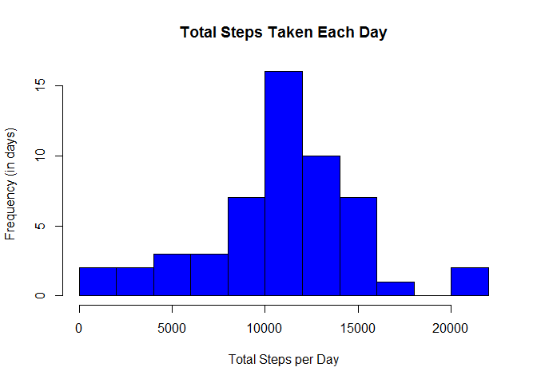

```r
dataNoNA <- data[!(is.na(data$steps)),]
dataByDay <- aggregate(dataNoNA$steps, by = list(dataNoNA$date), sum)
names(dataByDay) <- c('date', 'sum_of_steps')
hist(dataByDay$sum_of_steps, col = "blue", main = "Total Steps Taken Each Day", xlab = "Total Steps per Day", ylab = "Frequency (in days)", breaks = 10)
```

Now we want to calculate the mean and median total number of steps taken per day.

```r
meanStepsPerDay <- mean(dataByDay$sum_of_steps)
medianStepsPerDay <- median(dataByDay$sum_of_steps)
```

## What is the average daily activity pattern?

Now we will make a time series plot of the 5-minute interval and the average number of steps taken, averaged across all days.

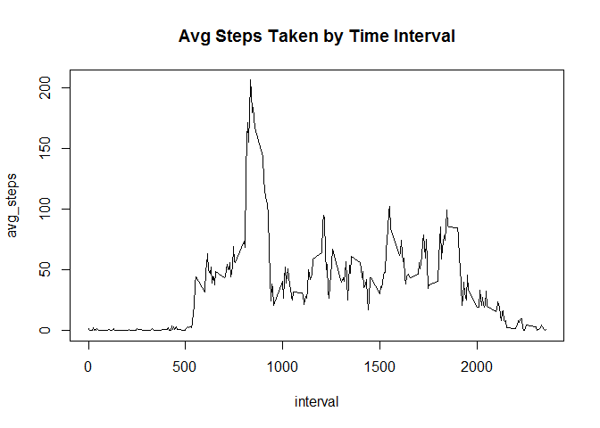

```r
dataByInterval <- aggregate(dataNoNA$steps, by = list(dataNoNA$interval), mean)
names(dataByInterval) <- c('interval', 'avg_steps')
with(dataByInterval, plot(interval, avg_steps, type = 'l', main = 'Avg Steps Taken by Time Interval'))
```

Perform the calculation below to determine which 5-minute interval throughout the day contains the maximum number of steps, on average:

```r
max <- max(dataByInterval$avg_steps)
intervalWithMaxSteps <- dataByInterval[dataByInterval$avg_steps == max,][1,1]
```

From the above calculation, we can see that the 5-minute interval (averaged across all days) containing the maximum number of steps is **835**. This is consistent with the graph above, because the spike appears to occur between intervals 750 and 1000.

## Imputing missing values

First we would like to computing the total number of missing values (coded as NA) in the dataset. The returned value after the code chunk below is the count of NAs:

```r
count <- 0
for(row in seq(length(data$steps))) {
  if(is.na(data$steps[row])) {
    count <- count + 1
  }
}
count
```

```
## [1] 2304
```

In order to remove potential bias from our data set, we will replace all 2304 NA values with the mean for that 5-minute interval across all days.

```r
merged <- merge(x = data, y = dataByInterval, by = 'interval')
merged$non_na_steps <- ifelse(is.na(merged$steps), merged$avg_steps, merged$steps)
dataImputed <- merged[,c('non_na_steps', 'date', 'interval')]
```

Now we will make a histogram similar to the one we made above, except this time we will use the new imputed dataset.

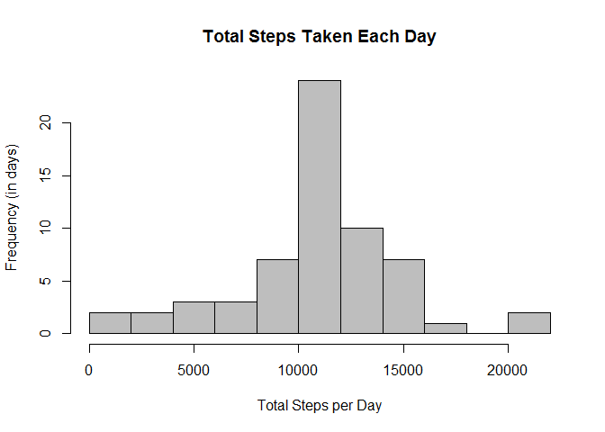

```r
dataImputedByDay <- aggregate(dataImputed$non_na_steps, by = list(dataImputed$date), sum)
names(dataImputedByDay) <- c('date', 'sum_of_steps')
hist(dataImputedByDay$sum_of_steps, col = "grey", main = "Total Steps Taken Each Day", xlab = "Total Steps per Day", ylab = "Frequency (in days)", breaks = 10)
```

```r
meanImputed <- mean(dataImputedByDay$sum_of_steps)
medianImputed <- median(dataImputedByDay$sum_of_steps)
```

## Are there differences in activity patterns between weekdays and weekends?

```r
dataImputed$day_type <- as.factor(ifelse(weekdays(as.Date(dataImputed$date)) %in% c('Saturday', 'Sunday'), 'weekend', 'weekday'))
head(dataImputed)
```

```
##   non_na_steps       date interval day_type
## 1     1.716981  10/1/2012        0  weekday
## 2     0.000000 11/23/2012        0  weekday
## 3     0.000000 10/28/2012        0  weekday
## 4     0.000000  11/6/2012        0  weekday
## 5     0.000000 11/24/2012        0  weekday
## 6     0.000000 11/15/2012        0  weekday
```

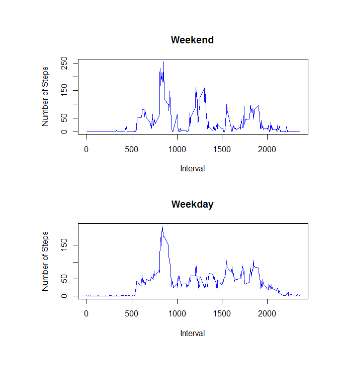

```r
par(mfcol = c(2, 1), oma = c(4, 4, 2, 1))

# create the weekend graph first
weekend <- dataImputed[dataImputed$day_type == "weekend",]
weekendAgg <- aggregate(weekend$non_na_steps, by = list(weekend$interval), mean)
names(weekendAgg) <- c('interval', 'avg_steps')
with(weekendAgg, plot(interval, avg_steps, type = 'l', col = 'blue', main = "Weekend", xlab = "Interval", ylab = "Number of Steps"))

# now create the weekday graph
weekday <- dataImputed[dataImputed$day_type == "weekday",]
weekdayAgg <- aggregate(weekday$non_na_steps, by = list(weekday$interval), mean)
names(weekdayAgg) <- c('interval', 'avg_steps')
with(weekdayAgg, plot(interval, avg_steps, type = 'l', col = 'blue', main = "Weekday", xlab = "Interval", ylab = "Number of Steps"))
```